# Projek KAPSEL FISKOM 117

## Dosen Pengampu: Dr. Bambang Heru I, M.Si

## Implementasi Metode Crank-Nicolson dalam Penyelesaian Persamaan Differensial Konduksi Panas

Kelompok 4:

- Abdullah Muadz Muflih - 1306620078
- Bagas Anwar Arif Nur - 1306620074
- Difa Farhani Hakim - 1306620040

# Latar Belakang

Persamaan diferensial parsial adalah suatu persamaan satu atau lebih turunan parsial dengan dua atau lebih variabel bebas. Dalam praktiknya terdapat banyak kasus yang termasuk persamaan diferensial parsial. Dengan berbagai kasus ini persamaan diferensial parsial terbagi menjadi beberapa bentuk diantaranya adalah:

- Persamaan Laplace
- Persamaan parabolic
- Persamaan Gelombang

Dalam kasus kali ini kami akan melakukan percobaan mengenai persamaan parabolik dalam kasus difusi panas. Dalam penyelesaiannya sendiri, persamaan parabolic secara numerik dapat diselesaikan dengan 3 macam cara yaitu explicit, implicit, dan Crank-Nicolson.

- Explicit

  Metode explicit adalah metode yang juga disebut dengan metode forward euler. Pada metode ini nilai didapatkan dengan menurunkan posisi pada level waktu l (current) sehingga didapatkan nilai pada waktu l+1 (later)

$$k\frac{\partial^2T}{\partial x^2}=\frac{\partial T}{\partial t}$$$$k\frac{T_{i+1}^l-2T_{i}^l+T_{i-1}^l}{\Delta x^2}=\frac{T_{i}^{l+1}-T_{i}^l}{\Delta t}$$$$T_{i}^{l+1}=\lambda(T_{i+1}^l-2T_{i}^l+T_{i-1}^l)+T_{i}^l$$

- Implicit

  Metode implicit terkadang disebut juga metode backward euler, pada metode ini nilai didapatkan dengan menurunkan posisi pada level waktu t = l+1 (later). pada metode ini akan didapatkan persamaan yang membentuk matrix, sehingga dalam penyelesaiannya nilai-nilai untuk level l+1 didapat secara bersamaan

$$k\frac{T_{i+1}^{l+1}-2T_{i}^{l+1}+T_{i-1}^{l+1}}{\Delta x^2}=\frac{T_{i}^{l+1}-T_{i}^l}{\Delta t}$$$$-\lambda T_{i+1}^{l+1}+(1+2\lambda)T_{i}^{l+1} - \lambda T_{i+1}^{l+1}=T_{i}^{l}$$

- Crank-Nicolson

  Crank nicolson adalah salah satu metode penyelesaian parabolic yang juga menggunakan matrix dalam penyelesaiannya. Cranck-nicolson adalah penggabungan antara metode forward dan backward

  $$\frac{\partial^2T}{\partial x^2} = \frac{1}{2} \left [\frac{T_{i+1}^l-2T_{i}^l+T_{i-1}^l}{\Delta x^2}+\frac{T_{i+1}^{l+1}-2T_{i}^{l+1}+T_{i-1}^{l+1}}{\Delta x^2} \right]$$

Dipisah antara temperatur waktu setelahnya dengan temperatur waktu saat ini dengan memindahkan variabel $T^{l + 1}$ ke sebelah kiri dan $T^{l} $ ke sebelah kanan

$$ -\lambda T_{i-1}^{l+1}+2(1+\lambda)T_{i}^{l+1}-\lambda T_{i+1}^{l+1}=\lambda T_{i-1}^{l}+2(1-\lambda)T_{i}^{l}+\lambda T_{i+1}^{l}$$

Pada percobaan ini kami akan mencoba menyelesaikan persaman difusi dengan menggunakan ketiga metode tersebut dan membandingkan hasil serta waktu running yang dibutuhkan untuk setiap metode.

# Permasalahan

## 20.4.2 Implementasi Metode Crank-Nicolson (Buku Landau Hal 490)

1. Menyelesaikan persoalan pada 20.1 dengan time step paling sedikit 100 step
2. Menyelesaikan sistem persamaan linear pada persamaan 20.32 dengan numpy atau algoritma tridiagonal special
3. Membuat plot kontur temperatur, posisi, dan waktu
4. Membuat animasi perubahan temperatur dengan matplotlib
5. Membandingkan hasil penyelesaiaan dengan menggunakan metode explicit (Beda Hingga), implicit, dan crank-nicolson

## Persoalan 20.1

Sebuah bar aluminum dengan panjang L = 1 m memilliki kondisi: $$T(x=0,t) = T(x=L,t) = 0 ^o C$$ $$T(x,t=0) = 100 ^o C$$ $$K' = 237 \frac{W}{mC}$$ $$C_{\rho} = 900 \frac{J}{kgC}$$ $$\rho = 2700 \frac{kg}{m^3}$$

$$ K = \frac{K'}{C_{\rho} \cdot \rho} $$

Tentukan temperatur pada titik tengah bar alumunium pada detik t = 10 s, t = 100 s, t = 500 s, t = 2500 s, dan t = 5000 s.

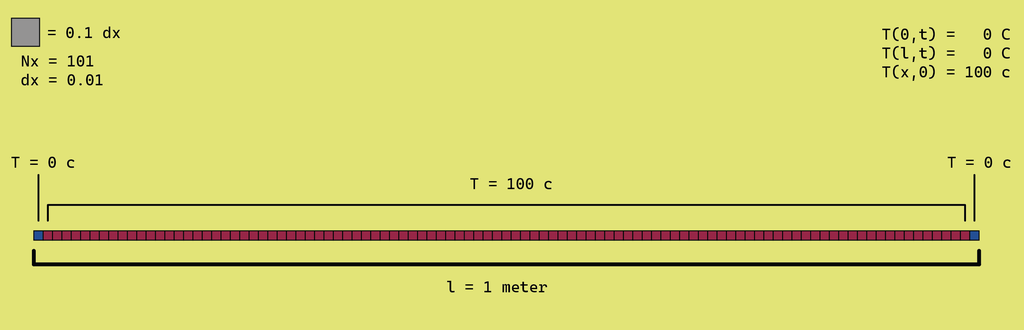

# Metode Penyelesaian

## Persamaan Konduksi Panas:

$$\frac{K}{C_\rho} \nabla^2 T(x,t)= \frac{\partial T(x,t)}{\partial t}$$

## Explicit (beda hingga)

Aproksimasi differensial dengan menggunakan metode beda hingga:

$$k\frac{\partial^2T}{\partial x^2}=\frac{\partial T}{\partial t}$$$$k\frac{T_{i+1}^l-2T_{i}^l+T_{i-1}^l}{\Delta x^2}=\frac{T_{i}^{l+1}-T_{i}^l}{\Delta t}$$$$\frac{k \Delta t}{\Delta x^2}[(T_{i+1}^l-2T_{i}^l+T_{i-1}^l) = T_{i}^{l+1}-T_{i}^l$$$$\lambda = \frac{k \Delta t}{\Delta x^2}$$$$T_{i}^{l+1}=T_{i}^l + \lambda(T_{i+1}^l-2T_{i}^l+T_{i-1}^l)$$

## Implicit

$$k\frac{\partial^2T}{\partial x^2}=\frac{\partial T}{\partial t}$$$$k\frac{T_{i+1}^{l+1}-2T_{i}^{l+1}+T_{i-1}^{l+1}}{\Delta x^2}=\frac{T_{i}^{l+1}-T_{i}^l}{\Delta t}$$$$-\lambda T_{i+1}^{l+1}+(1+2\lambda)T_{i}^{l+1} - \lambda T_{i+1}^{l+1}=T_{i}^{l}$$

Pada i = 1 $$(1+2\lambda)T_{1}^{l+1} - \lambda T_{2}^{l+1} = T_{1}^{l}+\lambda f_{0}(t^{l+1})$$

Pada i = m $$- \lambda T_{m-1}^{l+1} + (1+2\lambda)T_{m}^{l+1} = T_{m}^{l}+\lambda f_{m+1}(t^{l+1})$$

$$ \begin{bmatrix} 1+2\lambda & -\lambda & 0 & \dots & ...0 \\ -\lambda & 1+2\lambda & -\lambda & \dots & ...0 \\ 0 & \ddots & \ddots & \ddots & 0 \\ \vdots & \vdots & -\lambda & 1+2\lambda & -\lambda \\ ...0 & ...0 & 0 &-\lambda & 1+2\lambda \end{bmatrix} \begin{bmatrix} T_{1}^{l+1}\\ T_{2}^{l+1} \\ T_{3}^{l+1} \\ \vdots \\ T_{m}^{l+1} \end{bmatrix} = \begin{bmatrix} T_{1}^{l}+\lambda f_{0}^{l}\\ T_{2}^{l} \\ T_{3}^{l} \\ \vdots \\ T_{m}+\lambda f_{m+1}^{l} \end{bmatrix} $$

## Crank-Nicolson

$$\frac{\partial^2T}{\partial x^2} = \frac{1}{2} \left [\frac{T_{i+1}^l-2T_{i}^l+T_{i-1}^l}{\Delta x^2}+\frac{T_{i+1}^{l+1}-2T_{i}^{l+1}+T_{i-1}^{l+1}}{\Delta x^2} \right]$$

Dipisah antara temperatur waktu setelahnya dengan temperatur waktu saat ini dengan memindahkan variabel $T^{l + 1}$ ke sebelah kiri dan $T^{l} $ ke sebelah kanan

$$ -\lambda T_{i-1}^{l+1}+2(1+\lambda)T_{i}^{l+1}-\lambda T_{i+1}^{l+1}=\lambda T_{i-1}^{l}+2(1-\lambda)T_{i}^{l}+\lambda T_{i+1}^{l}$$

Selanjutnya, kita dapat menghitung nilai awal temperatur dan nilai akhir temperatur dengan menginput nilai i = 1 dan i = m.

i = 1 $$ 2(1+\lambda)T_{1}^{l+1} - \lambda T_{2}^{l+1} = \lambda f_{0}(t^{l})+2(1-\lambda)T_{1}^{l}+\lambda T_{2}^{l}+\lambda f_{0}(t^{l+1})$$

i = m $$ -\lambda T_{m-1}^{l+1}+2(1+\lambda)T_{m}^{l+1}=\lambda f_{m+1}(t^{l})+2(1-\lambda)T_{m}^{l}+\lambda T_{m-1}^{l}+\lambda f_{m+1}(t^{l+1})$$

$$ \begin{bmatrix} 2+2\lambda & -\lambda & 0 & \dots & ...0 \\ -\lambda & 2+2\lambda & -\lambda & \dots & ...0 \\ 0 & \ddots & \ddots & \ddots & 0 \\ \vdots & \vdots & -\lambda & 2+2\lambda & -\lambda \\ ...0 & ...0 & 0 &-\lambda & 2+2\lambda \end{bmatrix} \begin{bmatrix} T_{1}^{l+1}\\ T_{2}^{l+1} \\ T_{3}^{l+1} \\ \vdots \\ T_{m}^{l+1} \end{bmatrix} = \begin{bmatrix} 2-2\lambda & \lambda & 0 & \dots & ...0 \\ \lambda & 2-2\lambda & \lambda & \dots & ...0 \\ 0 & \ddots & \ddots & \ddots & 0 \\ \vdots & \vdots & \lambda & 2-2\lambda & \lambda \\ ...0 & ...0 & 0 &\lambda & 2-2\lambda \end{bmatrix} \begin{bmatrix} T_{1}^{l}\\ T_{2}^{l} \\ T_{3}^{l} \\ \vdots \\ T_{m-1} \end{bmatrix} + \begin{bmatrix} \lambda (T_{0}^{l} + T_{0}^{l+1})\\0 \\ 0 \\ \vdots \\ \lambda (T_{m+1}^{l} + T_{m+1}^{l+1}) \end{bmatrix}$$

## Analytic

$$T(x,t) = \frac{400}{\pi} \sum_{n = \text{odd}} \frac{1}{n} e^{-(\frac{n \pi \alpha}{L})^2 t} \sin{\frac{n \pi x}{L}}$$

## Error Percentage

$$ Error \% = \frac{|T_{numeric} - T_{analytic}|}{T_{analytic}} \cdot 100 \% $$

# Hasil Komputasi

```python
import numpy as np
import sympy as sp
from sympy import I, oo, Sum, exp, pi, sin

import matplotlib.pyplot as plt
import pandas as pd
import seaborn as sns

from matplotlib import animation
from matplotlib.animation import PillowWriter

import time
```

```python
start_time = time.time()
```

```python
np.set_printoptions(precision = 4, suppress=True)
pd.options.display.float_format = '{:.5f}'.format
```

## Explicit Method

```python
Nx = 101
Nt = 100_000
dx = 1/(Nx-1)
dt = 0.1
x = np.linspace(0, 1, Nx)

kp = 237
C = 900
rho = 2700
k = kp/(C*rho)
lamb = k * dt/(dx**2)
```

```python
M2 = np.zeros([Nt,Nx], dtype=float)
M2[0] = 100.
M2[:,0] = 0.
M2[:,Nx-1] = 0.
```

```python
def explicit_method(Temp):
    for t in range(0, Nt-1):
        for i in range(1, Nx-1):
            Temp[t+1][i] = Temp[t][i] + lamb * (Temp[t][i+1] - 2*Temp[t][i] + Temp[t][i-1])
    return Temp
```

```python
t_100 = 100
t_1000 = 1000
t_5000 = 5000
t_10000 = 10000
t_25000 = 25000
t_50000 = 50000
```

```python
%%time
TEMP_exp01 = np.copy(M2)
result_exp01 = explicit_method(TEMP_exp01)
```

```
CPU times: user 16.7 s, sys: 38.2 ms, total: 16.8 s
Wall time: 16.8 s
```

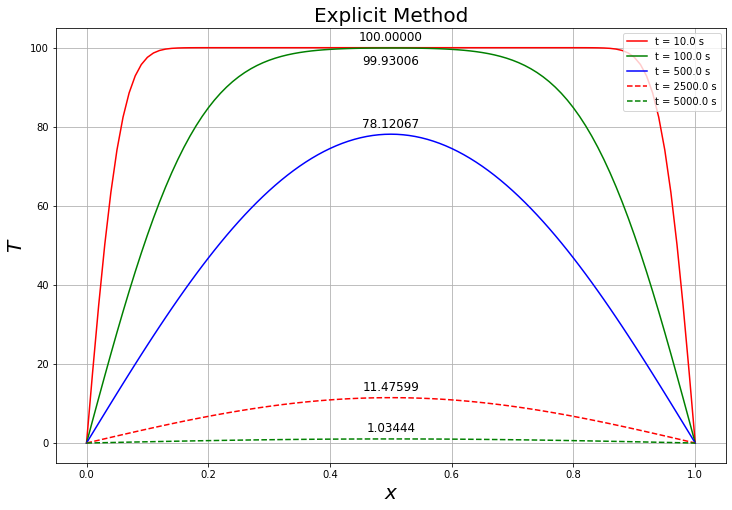

```python
fig, ax = plt.subplots(figsize=(12,8))
fig.patch.set_facecolor('xkcd:white')
plt.plot(x,result_exp01[t_100],color='red',label='t = {:.1f} s'.format(t_100*dt))
plt.plot(x,result_exp01[t_1000],color='green',label='t = {:.1f} s'.format(t_1000*dt))
plt.plot(x,result_exp01[t_5000],color='blue',label='t = {:.1f} s'.format(t_5000*dt))
plt.plot(x,result_exp01[t_25000],'--',color='red',label='t = {:.1f} s'.format(t_25000*dt))
plt.plot(x,result_exp01[t_50000],'--',color='green',label='t = {:.1f} s'.format(t_50000*dt))
ax.text(0.5,result_exp01[t_100][50] + 1,'{:.5f}'.format(result_exp01[t_100][50]), horizontalalignment='center',
        verticalalignment='bottom',size = 12)
ax.text(0.5,result_exp01[t_1000][50] - 5,'{:.5f}'.format(result_exp01[t_1000][50]), horizontalalignment='center',
        verticalalignment='bottom',size = 12)
ax.text(0.5,result_exp01[t_5000][50] + 1,'{:.5f}'.format(result_exp01[t_5000][50]), horizontalalignment='center',
        verticalalignment='bottom',size = 12)
ax.text(0.5,result_exp01[t_25000][50] + 1,'{:.5f}'.format(result_exp01[t_25000][50]), horizontalalignment='center',
        verticalalignment='bottom',size = 12)
ax.text(0.5,result_exp01[t_50000][50] + 1,'{:.5f}'.format(result_exp01[t_50000][50]), horizontalalignment='center',
        verticalalignment='bottom',size = 12)
ax.legend(loc='upper right')
ax.set_ylabel('$T$', fontsize=20)
ax.set_xlabel('$x$', fontsize=20)
ax.set_title('Explicit Method', fontsize= 20)
plt.grid()
plt.savefig('exp_plot.png')
```

## Implicit Method

```python
Nx = 101
Nt = 100_000
dx = 1/(Nx-1)
dt = 0.1
x = np.linspace(0, 1, Nx)
X_pos = Nx - 2

kp = 237
C = 900
rho = 2700
k = kp/(C*rho)
lamb = k * dt/(dx**2)
```

```python
A = np.diag([1 + 2*lamb]*X_pos,0) + np.diag([-lamb]*(X_pos-1),-1) + np.diag([-lamb]*(X_pos-1),1)
M2 = np.zeros([Nt,Nx], dtype=float)
M2[0] = 100.
M2[:,0] = 0.
M2[:,Nx-1] = 0.
#A, B
```

```python
def implicit_method(Temp):
    RHS = np.copy(M2)
    RHS_old = np.copy(RHS)
    for j in range(0,Nt-1):
        i = 1
        RHS[j][i] = RHS[j][i] + lamb*RHS_old[j][i-1]

        i = X_pos
        RHS[j][i] = RHS[j][i] + lamb*RHS_old[j][i+1]

        RHS_input = RHS[j][1:-1]
        X_new = np.linalg.solve(A,RHS_input)

        Temp[j+1][1:-1] = X_new
        RHS[j+1][1:-1] = X_new
        RHS_old[j+1][1:-1] = np.copy(RHS_input)
    return Temp
```

```python
%%time
TEMP_imp01 = np.copy(M2)
result_imp01 = implicit_method(TEMP_imp01)
```

```
CPU times: user 1min 14s, sys: 47.1 s, total: 2min 1s
Wall time: 31.3 s
```

```python
t_100 = 100
t_1000 = 1000
t_5000 = 5000
t_10000 = 10000
t_25000 = 25000
t_50000 = 50000
```

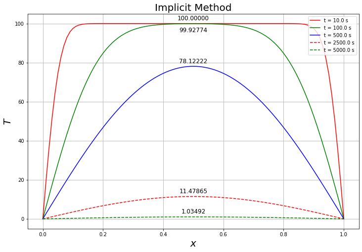

```python
fig, ax = plt.subplots(figsize=(12,8))
fig.patch.set_facecolor('xkcd:white')
plt.plot(x,result_imp01[t_100],color='red',label='t = {:.1f} s'.format(t_100*dt))
plt.plot(x,result_imp01[t_1000],color='green',label='t = {:.1f} s'.format(t_1000*dt))
plt.plot(x,result_imp01[t_5000],color='blue',label='t = {:.1f} s'.format(t_5000*dt))
plt.plot(x,result_imp01[t_25000],'--',color='red',label='t = {:.1f} s'.format(t_25000*dt))
plt.plot(x,result_imp01[t_50000],'--',color='green',label='t = {:.1f} s'.format(t_50000*dt))
ax.text(0.5,result_imp01[t_100][50] + 1,'{:.5f}'.format(result_imp01[t_100][50]), horizontalalignment='center',
        verticalalignment='bottom',size = 12)
ax.text(0.5,result_imp01[t_1000][50] - 5,'{:.5f}'.format(result_imp01[t_1000][50]), horizontalalignment='center',
        verticalalignment='bottom',size = 12)
ax.text(0.5,result_imp01[t_5000][50] + 1,'{:.5f}'.format(result_imp01[t_5000][50]), horizontalalignment='center',
        verticalalignment='bottom',size = 12)
ax.text(0.5,result_imp01[t_25000][50] + 1,'{:.5f}'.format(result_imp01[t_25000][50]), horizontalalignment='center',
        verticalalignment='bottom',size = 12)
ax.text(0.5,result_imp01[t_50000][50] + 1,'{:.5f}'.format(result_imp01[t_50000][50]), horizontalalignment='center',
        verticalalignment='bottom',size = 12)
ax.legend(loc='upper right')
ax.set_ylabel('$T$', fontsize=20)
ax.set_xlabel('$x$', fontsize=20)
ax.set_title('Implicit Method', fontsize= 20)
plt.grid()
plt.savefig('imp_plot.png')
```

## Crank-Nicolson Method

```python
Nx = 101
Nt = 100_000
dx = 1/(Nx-1)
dt = 0.1
x = np.linspace(0, 1, Nx)
X_pos = Nx - 2

kp = 237
C = 900
rho = 2700
k = kp/(C*rho)
lamb = k * dt/(dx**2)
```

```python
A = np.diag([2 + 2*lamb]*X_pos,0) + np.diag([-lamb]*(X_pos-1),-1) + np.diag([-lamb]*(X_pos-1),1)
B = np.diag([2 - 2*lamb]*X_pos,0) + np.diag([lamb]*(X_pos-1),-1) + np.diag([lamb]*(X_pos-1),1)
M2 = np.zeros([Nt,Nx], dtype=float)
M2[0] = 100.
M2[:,0] = 0.
M2[:,Nx-1] = 0.
#A, B
```

```python
def crank_nicolson(Temp):
    for j in range(0,Nt-1):
        b = np.dot(B,Temp[j][1:-1])

        i = 0
        b[i] += lamb*(Temp[j][i] + Temp[j+1][i])

        i = X_pos
        b[i-1] += lamb*(Temp[j][i+1] + Temp[j+1][i+1])

        X_new = np.linalg.solve(A,b)

        Temp[j+1][1:-1] = X_new
    return Temp
```

```python
%%time
TEMP_cn1 = np.copy(M2)
result_cn01 = crank_nicolson(TEMP_cn1)
```

```
CPU times: user 1min 14s, sys: 47.8 s, total: 2min 2s
Wall time: 31.3 s
```

```python
t_100 = 100
t_1000 = 1000
t_5000 = 5000
t_10000 = 10000
t_25000 = 25000
t_50000 = 50000
```

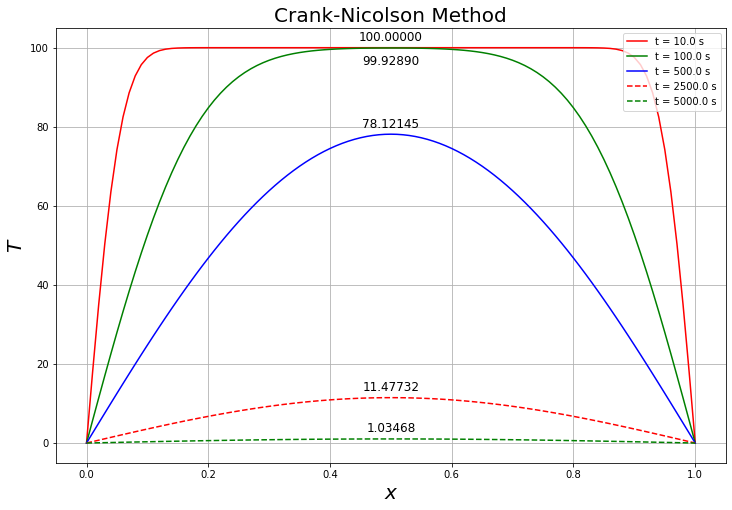

```python
fig, ax = plt.subplots(figsize=(12,8))
fig.patch.set_facecolor('xkcd:white')
plt.plot(x,result_cn01[t_100],color='red',label='t = {:.1f} s'.format(t_100*dt))
plt.plot(x,result_cn01[t_1000],color='green',label='t = {:.1f} s'.format(t_1000*dt))
plt.plot(x,result_cn01[t_5000],color='blue',label='t = {:.1f} s'.format(t_5000*dt))
plt.plot(x,result_cn01[t_25000],'--',color='red',label='t = {:.1f} s'.format(t_25000*dt))
plt.plot(x,result_cn01[t_50000],'--',color='green',label='t = {:.1f} s'.format(t_50000*dt))
ax.text(0.5,result_cn01[t_100][50] + 1,'{:.5f}'.format(result_cn01[t_100][50]), horizontalalignment='center',
        verticalalignment='bottom',size = 12)
ax.text(0.5,result_cn01[t_1000][50] - 5,'{:.5f}'.format(result_cn01[t_1000][50]), horizontalalignment='center',
        verticalalignment='bottom',size = 12)
ax.text(0.5,result_cn01[t_5000][50] + 1,'{:.5f}'.format(result_cn01[t_5000][50]), horizontalalignment='center',
        verticalalignment='bottom',size = 12)
ax.text(0.5,result_cn01[t_25000][50] + 1,'{:.5f}'.format(result_cn01[t_25000][50]), horizontalalignment='center',
        verticalalignment='bottom',size = 12)
ax.text(0.5,result_cn01[t_50000][50] + 1,'{:.5f}'.format(result_cn01[t_50000][50]), horizontalalignment='center',
        verticalalignment='bottom',size = 12)
ax.legend(loc='upper right')
ax.set_ylabel('$T$', fontsize=20)
ax.set_xlabel('$x$', fontsize=20)
ax.set_title('Crank-Nicolson Method', fontsize= 20)
plt.grid()
plt.savefig('cn_plot.png')
```

## Analytical Parabolic dengan Sympy

```python
x, n, t, L = sp.symbols('x n t L')
```

```python
x_ipt = 0.5

kp = 237
C = 900
rho = 2700
K = np.sqrt(kp/(C*rho))
```

```python
def sp_par_t(T):
    sum_func = 1/n * sin(n*pi*x) * exp(-(n*pi*K)**2*t)
    s_sub = sum_func.subs([(x, x_ipt), (t, T)])
    Hasil_sumasi = Sum(s_sub, (n,1,oo)).doit().evalf()
    func = 400/ pi * Hasil_sumasi

    return func.evalf()
```

```python
ana_t10 = sp_par_t(10)
ana_t100 = sp_par_t(100)
ana_t500 = sp_par_t(500)
ana_t2500 = sp_par_t(2500)
ana_t5000 = sp_par_t(5000)
```

## Table

```python
t_10s = 100
t_100s = 1000
t_500s = 5000
t_2500s = 25000
t_5000s = 50000

waktu = [t_10s, t_10s,t_500s,t_2500s,t_5000s]

exp = [result_exp01[t_10s][50],result_exp01[t_100s][50],result_exp01[t_500s][50],result_exp01[t_2500s][50],result_exp01[t_5000s][50]]
imp = [result_imp01[t_10s][50],result_imp01[t_100s][50],result_imp01[t_500s][50],result_imp01[t_2500s][50],result_imp01[t_5000s][50]]
cn = [result_cn01[t_10s][50],result_cn01[t_100s][50],result_cn01[t_500s][50],result_cn01[t_2500s][50],result_cn01[t_5000s][50]]
ana = [ana_t10,ana_t100,ana_t500,ana_t2500,ana_t5000]
```

```python
df_table = pd.DataFrame({'Waktu (s)': waktu, 'Analytic': ana, 'Explicit': exp, 'Implicit': imp, 'Crank-Nicolson': cn})
print(df_table)
```

```
   Waktu (s)          Analytic  Explicit  Implicit  Crank-Nicolson
0        100  100.000000000000 100.00000 100.00000       100.00000
1        100  99.9312832041463  99.93006  99.92774        99.92890
2       5000  78.1261756236531  78.12067  78.12222        78.12145
3      25000  11.4759901923004  11.47599  11.47865        11.47732
4      50000  1.03435643214788   1.03444   1.03492         1.03468
```

## Error

```python
def err_ana(Temp):
    n = len(Temp)
    err = np.zeros(n)
    for i in range(n):
        err[i] = np.abs(Temp[i] - ana[i])/ana[i]*100
    return err
```

```python
err_exp = err_ana(exp)
err_imp = err_ana(imp)
err_cn = err_ana(cn)
```

```python
pd.set_option('display.float_format', lambda x: '%.5f' % x)
```

```python
df_err = pd.DataFrame({'Waktu (s)': waktu, 'Err% Exp': err_exp, 'Err% Imp': err_imp, 'Err% CN': err_cn})
print(df_err)
```

```
   Waktu (s)  Err% Exp  Err% Imp  Err% CN
0        100   0.00000   0.00000  0.00000
1        100   0.00122   0.00354  0.00238
2       5000   0.00705   0.00506  0.00605
3      25000   0.00001   0.02315  0.01157
4      50000   0.00820   0.05453  0.03136
```

## Save - Load Result

```python
# np.save('result_exp01.npy', result_exp01)
# np.save('result_imp01.npy', result_imp01)
# np.save('result_cn01.npy', result_cn01)
```

```python
# result_cn01 = np.load('result_cn01.npy',allow_pickle=True)
# result_imp01 = np.load('result_imp01.npy',allow_pickle=True)
# result_exp01 = np.load('result_exp01.npy',allow_pickle=True)
```

## Kontur

```python
def contour3dangle(x_len,dt,t_len,T_arr,list_view):
    t_arr = np.arange(0,t_len,dtype='float64')*0.1
    x_arr = np.linspace(0,1,x_len)
    X,Y = np.meshgrid(x_arr, t_arr)
    fig = plt.figure(figsize=(15,15))
    fig.patch.set_facecolor('xkcd:white')
    for i in range(1,len(list_view)+1):
        ax = fig.add_subplot(3,2,i, projection='3d')
        surf = ax.plot_surface(X, Y, T_arr,cmap='plasma', edgecolor='none')
        ax.set_xlabel('Posisi')
        ax.set_ylabel('Time')
        ax.set_zlabel('Suhu')
        ax.view_init(list_view[i-1][0],list_view[i-1][1])
        ax.set_title(f'View Ele:{list_view[i-1][0]} Azi:{list_view[i-1][1]}')
        fig.colorbar(surf, shrink=20, aspect=4)
    return

def contour3dtime(x_len,dt,t_len,T_arr,list_time):
    t_arr = np.arange(0,t_len,dtype='float64')*0.1
    x_arr = np.linspace(0,1,x_len)
    X,Y = np.meshgrid(x_arr, t_arr)
    fig = plt.figure(figsize=(15,15))
    fig.patch.set_facecolor('xkcd:white')
    for i in range(1,len(list_time)+1):
        ax = fig.add_subplot(3,2,i, projection='3d')
        surf = ax.plot_surface(X[:list_time[i-1]], Y[:list_time[i-1]], T_arr[:list_time[i-1]],cmap='plasma', edgecolor='none')
        ax.set_xlabel('Posisi')
        ax.set_ylabel('Time')
        ax.set_zlabel('Suhu')
        ax.set_title(f'Running {list_time[i-1]*0.1}s')
        ax.view_init(10,40)
        fig.colorbar(surf, shrink=20, aspect=4)
    return
```

```python
list_view = [[10,40],[10,90],[10,180]]
list_time = [100,1000,5000,10000,25000,50000]
```

### Explicit

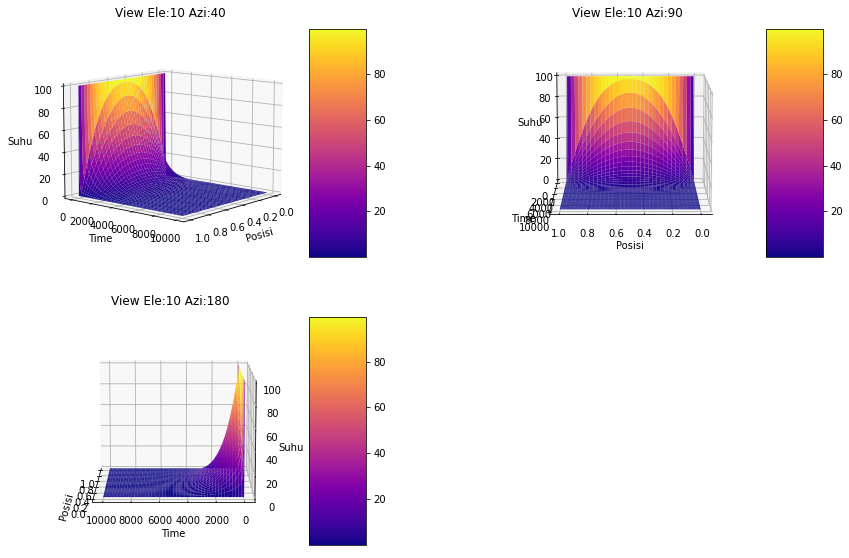

```python
contour3dangle(Nx,dt,Nt,result_exp01,list_view)
plt.savefig('Exp_contour_view.png')
```

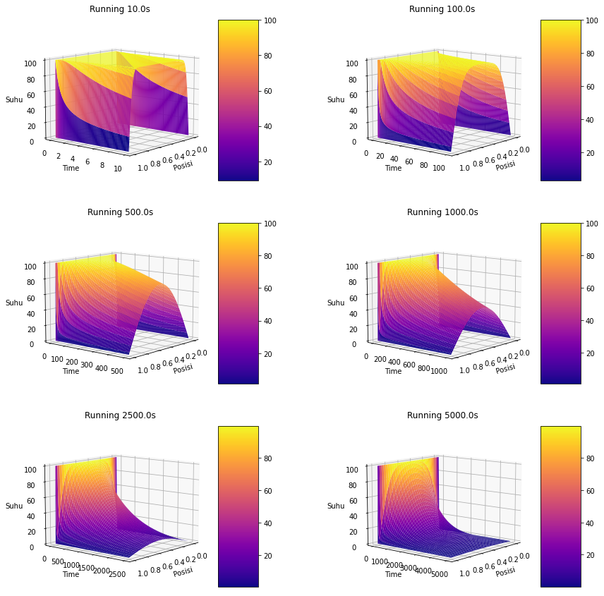

```python
contour3dtime(Nx,dt,Nt,result_exp01,list_time)
plt.savefig('Exp_contour_time.png')
```

### Implicit

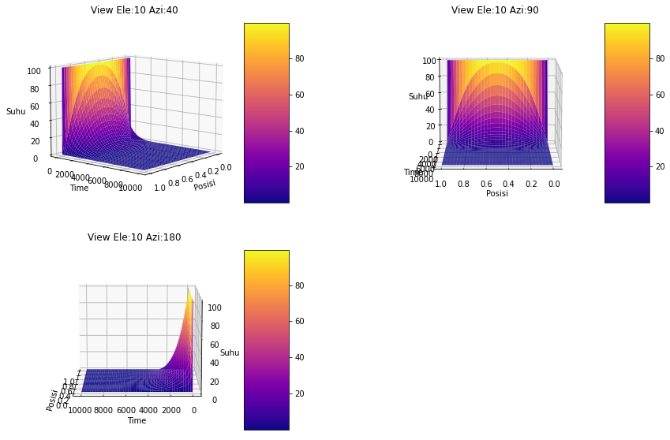

```python
contour3dangle(Nx,dt,Nt,result_imp01,list_view)
plt.savefig('Imp_contour_view.png')
```

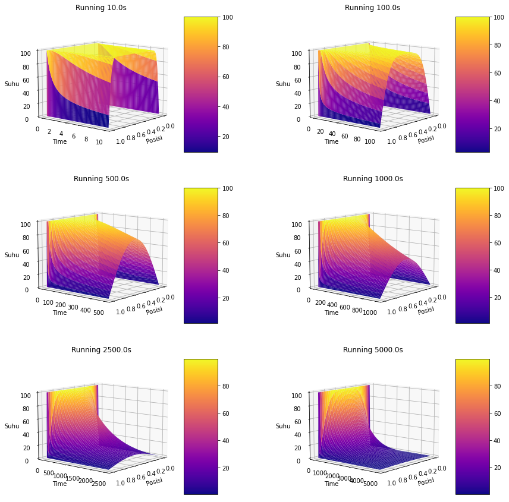

```python
contour3dtime(Nx,dt,Nt,result_imp01,list_time)
plt.savefig('Imp_contour_time.png')
```

### Crank-Nicolson

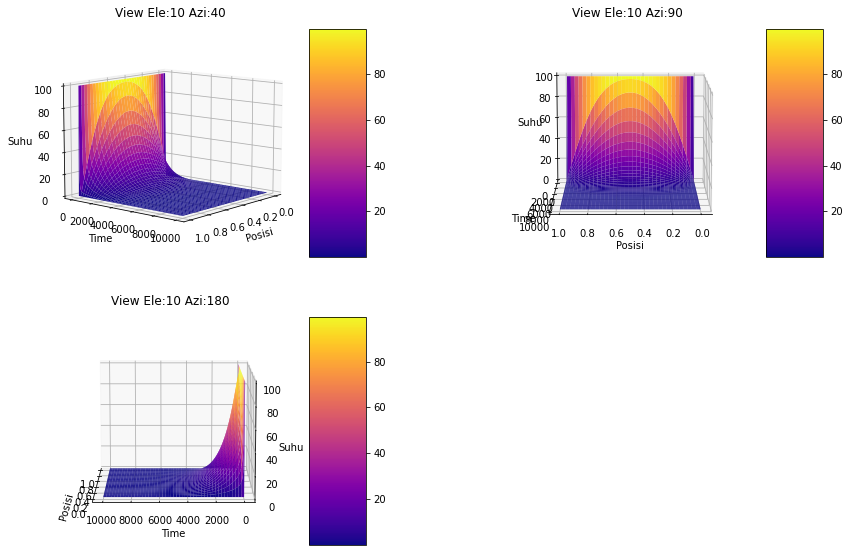

```python
contour3dangle(Nx,dt,Nt,result_cn01,list_view)
plt.savefig('cn_contour_view.png')
```

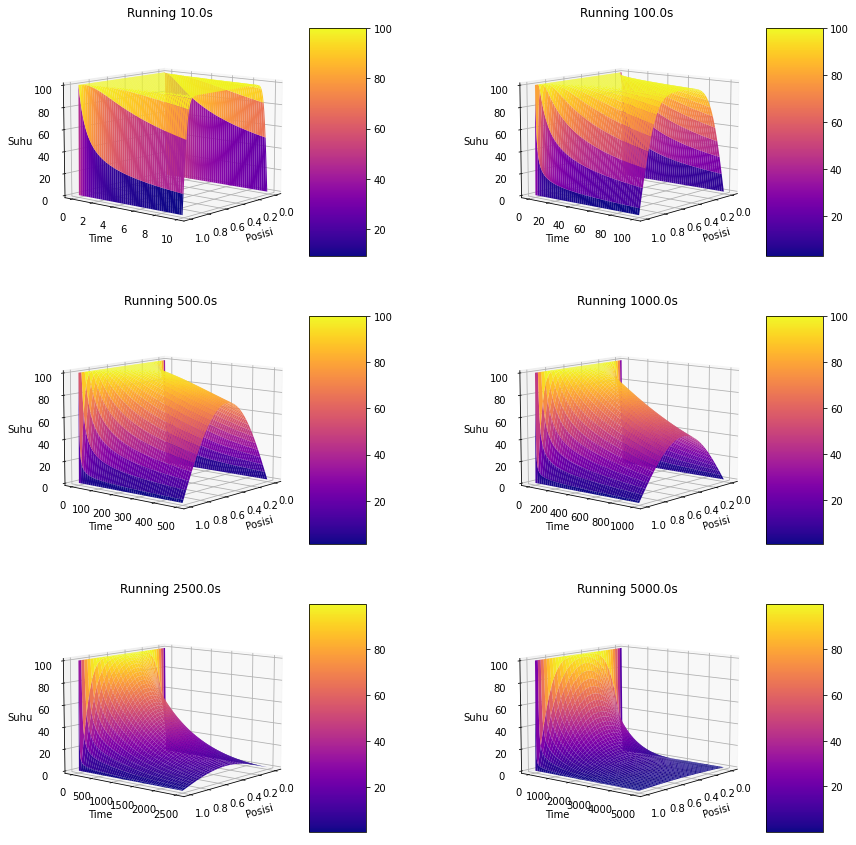

```python
contour3dtime(Nx,dt,Nt,result_cn01,list_time)
plt.savefig('cn_contour_time.png')
```

## Variasi dengan step size berbeda

### dt = 1

```python
Nx = 101
Nt = 100_000
dx = 1/(Nx-1)
dt_1 = 1
x = np.linspace(0, 1, Nx)
X_pos = Nx - 2

kp = 237
C = 900
rho = 2700
k = kp/(C*rho)
lamb = k * dt_1/(dx**2)

A = np.diag([2 + 2*lamb]*X_pos,0) + np.diag([-lamb]*(X_pos-1),-1) + np.diag([-lamb]*(X_pos-1),1)
B = np.diag([2 - 2*lamb]*X_pos,0) + np.diag([lamb]*(X_pos-1),-1) + np.diag([lamb]*(X_pos-1),1)
M2 = np.zeros([Nt,Nx], dtype=float)
M2[0] = 100.
M2[:,0] = 0.
M2[:,Nx-1] = 0.

TEMP_exp1 = np.copy(M2)
result_exp1 = explicit_method(TEMP_exp1)
TEMP_cn1 = np.copy(M2)
result_cn1 = crank_nicolson(TEMP_cn1)

A = np.diag([1 + 2*lamb]*X_pos,0) + np.diag([-lamb]*(X_pos-1),-1) + np.diag([-lamb]*(X_pos-1),1)
M2 = np.zeros([Nt,Nx], dtype=float)
M2[0] = 100.
M2[:,0] = 0.
M2[:,Nx-1] = 0.
#A, B

TEMP_imp1 = np.copy(M2)
result_imp1 = implicit_method(TEMP_imp1)
```

### dt = 0.2

```python
Nx = 101
Nt = 100_000
dx = 1/(Nx-1)
dt_02 = 0.2
x = np.linspace(0, 1, Nx)
X_pos = Nx - 2

kp = 237
C = 900
rho = 2700
k = kp/(C*rho)
lamb = k * dt_02/(dx**2)

A = np.diag([2 + 2*lamb]*X_pos,0) + np.diag([-lamb]*(X_pos-1),-1) + np.diag([-lamb]*(X_pos-1),1)
B = np.diag([2 - 2*lamb]*X_pos,0) + np.diag([lamb]*(X_pos-1),-1) + np.diag([lamb]*(X_pos-1),1)
M2 = np.zeros([Nt,Nx], dtype=float)
M2[0] = 100.
M2[:,0] = 0.
M2[:,Nx-1] = 0.

TEMP_exp02 = np.copy(M2)
result_exp02 = explicit_method(TEMP_exp02)
TEMP_cn02 = np.copy(M2)
result_cn02 = crank_nicolson(TEMP_cn02)

A = np.diag([1 + 2*lamb]*X_pos,0) + np.diag([-lamb]*(X_pos-1),-1) + np.diag([-lamb]*(X_pos-1),1)
M2 = np.zeros([Nt,Nx], dtype=float)
M2[0] = 100.
M2[:,0] = 0.
M2[:,Nx-1] = 0.
#A, B

TEMP_imp02 = np.copy(M2)
result_imp02 = implicit_method(TEMP_imp02)
```

```python
step_size = [dt_1,dt_02,0.1]
exp_step = [result_exp1[10][2],result_exp02[50][2],result_exp01[100][2]]
imp_step = [result_imp1[10][2],result_imp02[50][2],result_imp01[100][2]]
cn_step = [result_cn1[10][2],result_cn02[50][2],result_cn01[100][2]]
```

```python
df_dt = pd.DataFrame({'Step Size (dt)': step_size, 'Explicit': exp_step, 'Implicit' : imp_step, 'Crank-Nicolson': cn_step})
```

```python
print(f'Nilai $\lambda$ untuk dt = {dt_02} dan dx = {dx} adalah {k * dt_02/(dx**2)}')
print(f'Nilai $\lambda$ untuk dt = {dt_1} dan dx = {dx} adalah {k * dt_1/(dx**2)}\n')
print(df_dt)
```

```
Nilai $\lambda$ untuk dt = 0.2 dan dx = 0.01 adalah 0.19506172839506175
Nilai $\lambda$ untuk dt = 1 dan dx = 0.01 adalah 0.9753086419753085

   Step Size (dt)     Explicit  Implicit  Crank-Nicolson
0         1.00000 -69471.03031  36.17085        34.94547
1         0.20000     34.76201  35.21993        34.98768
2         0.10000     34.87535  35.10431        34.98901
```

## Visualisasi Simulasi

Visualisasi simulasi terdiri dari file dengan format .mp4 plotting metode explicit, implicit, dan crank-nicolson serta kontur dengan menggunakan library matplotlib.animation.

### Explicit

```python
# %%time
# def animate(i):
#     ln1.set_data(x, result_exp01[100*i])
#     time_text.set_text('$t = ${:.1f} s'.format(100*i*dt))
#     temp_text.set_text('$T(0.5,t) = ${:.2f} $^o C$'.format(result_exp01[100*i][50]))

# fig, ax = plt.subplots(1,1, figsize=(8,6))
# fig.patch.set_facecolor('xkcd:white')
# ax.grid()
# ln1, = plt.plot([], [], 'r-', lw=2, markersize=8, label='Explicit')
# time_text = ax.text(.85, 50, '', fontsize=12,
#            bbox=dict(facecolor='white', edgecolor='black'))
# temp_text = ax.text(.75, 90, '', fontsize = 12,
#            bbox=dict(facecolor='white', edgecolor='black'))
# ax.set_ylim(-1, 101)
# ax.set_xlim(0,1)
# ax.set_ylabel('$T$', fontsize=20)
# ax.set_xlabel('$x$', fontsize=20)
# ax.legend(loc='upper left')
# ax.set_title('Explicit Method', fontsize=20)
# plt.tight_layout()
# ani = animation.FuncAnimation(fig, animate, frames=1000, interval=50)
# ani.save('Exp_temp_ver-fix.gif',writer='pillow',fps=50,dpi=100)
```

### Implicit

```python
# %%time
# def animate(i):
#     ln1.set_data(x, result_imp01[100*i])
#     time_text.set_text('$t = ${:.1f} s'.format(100*i*dt))
#     temp_text.set_text('$T(0.5,t) = ${:.2f} $^o C$'.format(result_imp01[100*i][50]))

# fig, ax = plt.subplots(1,1, figsize=(8,6))
# fig.patch.set_facecolor('xkcd:white')
# ax.grid()
# ln1, = plt.plot([], [], 'r-', lw=2, markersize=8, label='Implicit')
# time_text = ax.text(.85, 50, '', fontsize=12,
#            bbox=dict(facecolor='white', edgecolor='black'))
# temp_text = ax.text(.75, 90, '', fontsize = 12,
#            bbox=dict(facecolor='white', edgecolor='black'))
# ax.set_ylim(-1, 101)
# ax.set_xlim(0,1)
# ax.set_ylabel('$T$', fontsize=20)
# ax.set_xlabel('$x$', fontsize=20)
# ax.legend(loc='upper left')
# ax.set_title('Implicit Method', fontsize=20)
# plt.tight_layout()
# ani = animation.FuncAnimation(fig, animate, frames=1000, interval=50)
# ani.save('Imp_temp_ver-fix.gif',writer='pillow',fps=50,dpi=100)
```

### Crank-Nicolson

```python
# %%time
# def animate(i):
#     ln1.set_data(x, result_cn01[100*i])
#     time_text.set_text('$t = ${:.1f} s'.format(100*i*dt))
#     temp_text.set_text('$T(0.5,t) = ${:.2f} $^o C$'.format(result_cn01[100*i][50]))

# fig, ax = plt.subplots(1,1, figsize=(8,6))
# fig.patch.set_facecolor('xkcd:white')
# ax.grid()
# ln1, = plt.plot([], [], 'r-', lw=2, markersize=8, label='Crank-Nicolson')
# time_text = ax.text(.85, 50, '', fontsize=12,
#            bbox=dict(facecolor='white', edgecolor='black'))
# temp_text = ax.text(.75, 90, '', fontsize = 12,
#            bbox=dict(facecolor='white', edgecolor='black'))
# ax.set_ylim(-1, 101)
# ax.set_xlim(0,1)
# ax.set_ylabel('$T$', fontsize=20)
# ax.set_xlabel('$x$', fontsize=20)
# ax.legend(loc='upper left')
# ax.set_title('Crank-Nicolson Method', fontsize=20)
# plt.tight_layout()
# ani = animation.FuncAnimation(fig, animate, frames=1000, interval=50)
# ani.save('CN_temp_ver-fix.gif',writer='pillow',fps=50,dpi=100)
```

### Gabungan

```python
# %%time
# def animate(i):
#     ln1.set_data(x, result_exp01[100*i])
#     ln2.set_data(x, result_imp01[100*i])
#     ln3.set_data(x, result_cn01[100*i])
#     time_text.set_text('$t = ${:.1f} s'.format(100*i*dt))

# fig, ax = plt.subplots(1,1, figsize=(8,6))
# fig.patch.set_facecolor('xkcd:white')
# ax.grid()
# ln1, = plt.plot([], [], 'r-', lw=2, markersize=6, label='Explicit')
# ln2, = plt.plot([], [], 'g--', lw=3, markersize=8, label='Implicit')
# ln3, = plt.plot([], [], 'b-', lw=4, markersize=10, label='Crank-Nicolson')
# time_text = ax.text(.85, 50, '', fontsize=12,
#            bbox=dict(facecolor='white', edgecolor='black'))
# temp_text = ax.text(.75, 90, '', fontsize = 12,
#            bbox=dict(facecolor='white', edgecolor='black'))
# ax.set_ylim(-1, 101)
# ax.set_xlim(0,1)
# ax.set_ylabel('$T$', fontsize=20)
# ax.set_xlabel('$x$', fontsize=20)
# ax.legend(loc='upper left')
# ax.set_title('Plot Gabungan', fontsize=20)
# plt.tight_layout()
# ani = animation.FuncAnimation(fig, animate, frames=1000, interval=50)
# ani.save('Gabung_temp_ver-fix.gif',writer='pillow',fps=50,dpi=100)
```

### Kontur

```python
# %%time
# t_arr = np.arange(0,Nt,dtype='float64')*5
# x_arr = np.linspace(0,1,Nx)
# x,y = np.meshgrid(x_arr, t_arr)

# fps = 60 # frame per sec
# frn = Nt # frame number of the animation

# bar = M2.copy()
# zarray = np.zeros((Nt, Nx, frn))

# for i in range (0,len(result_cn01),):
#     bar[i][:] = result_cn01[i][:]
#     zarray[:,:,i] = bar

# def update_plot(frame_number, zarray, plot):
#     plot[0].remove()
#     plot[0] = ax.plot_surface(x, y, zarray[:,:,2*frame_number], cmap="plasma")
#     ax.set_xlabel('Posisi')
#     ax.set_ylabel('Time')
#     ax.set_zlabel('Suhu')

# fig = plt.figure(figsize=(10,10))
# ax = fig.add_subplot(111, projection='3d')

# plot = [ax.plot_surface(x, y, zarray[:,:,0], cmap='plasma')]
# ax.view_init(10,40)
# ani = animation.FuncAnimation(fig, update_plot, 1000, fargs=(zarray, plot), interval=50)

# fn = 'plot_surface_animation_funcanimation'
# ani.save(fn+'.mp4',writer='ffmpeg',fps=fps)
# ani.save(fn+'.gif',writer='imagemagick',fps=fps)
```

```python
end_time = time.time()
print('Execution time = {:.4f} seconds'.format(end_time - start_time))
```

```
Execution time = 310.9572 seconds
```

# Analisis

## Temperatur dan Error

```python
print(df_table)
print(df_err)
```

```
   Waktu (s)          Analytic  Explicit  Implicit  Crank-Nicolson
0        100  100.000000000000 100.00000 100.00000       100.00000
1        100  99.9312832041463  99.93006  99.92774        99.92890
2       5000  78.1261756236531  78.12067  78.12222        78.12145
3      25000  11.4759901923004  11.47599  11.47865        11.47732
4      50000  1.03435643214788   1.03444   1.03492         1.03468
   Waktu (s)  Err% Exp  Err% Imp  Err% CN
0        100   0.00000   0.00000  0.00000
1        100   0.00122   0.00354  0.00238
2       5000   0.00705   0.00506  0.00605
3      25000   0.00001   0.02315  0.01157
4      50000   0.00820   0.05453  0.03136
```

Dari data perhitungan error tersebut di atas di atas kertas metode explicit memiliki error yang paling kecil, dilanjutkan oleh metode crank-nicolson lalu metode implicit. Namun, dari data tersebut juga terlihat bahwa error dari ketiga metode tersebut tidak memiliki perbedaan yang signifikan karena errornya sudah sangat kecil, sehingga ketiga metode ini dapat dikatakan memiliki hasil perhitungan dengan akurasi yang tinggi.

## Kontur

Pada percobaan ini dibuat 2 macam kontur untuk ketiga metode, satu adalah kontur yang sudut penglihatannya di atur dan satu kontur lainnya adalah kontur yang menunjukkan bentuk kontur untuk waktu tertentu. Pada kontur untuk ketiga metode ini didapati bentuk yang mirip, itu artinya untuk pengujian menggunakan ukuran $\Delta t = $ 0.1 dan $\Delta x = 0.01$ didapati hasil yang sama dan tidak error.

Pada kontur ini juga dapat dilihat bahwa semakin lama waktu berjalan semakin rendah juga suhu untuk sisi kanan dan kirinya. Pada waktu 10-1000 detik nilai suhu pada titik tengah masihlah berkisar T = 100-40 $^o C$, lalu pada waktu 2500 detik suhu sudah mulai turun ke nilai dibawah T = 20 $^o C$, lalu suhu mulai menuju ke T = 0 $^o C$ saat sudah mencapai waktu ke 5000 detik

## Variasi Step Size

```python
df_dt
```

|  | Step Size (dt) | Explicit | Implicit | Crank-Nicolson |
| --- | --- | --- | --- | --- |
| 0 | 1.00000 | -69471.03031 | 36.17085 | 34.94547 |
| 1 | 0.20000 | 34.76201 | 35.21993 | 34.98768 |
| 2 | 0.10000 | 34.87535 | 35.10431 | 34.98901 |

Selain dengan menggunakan $\Delta t = 0.1s$ dilakukan juga step size dengan $\Delta t = 0.2s$ dan $\Delta t = 1s$ dari hasil ini didapati pada detik ke 10 untuk titik 0.2 nilai suhu dengan metode explicit, implicit, dan crank nicolson pada step 0.1s adalah 34.87535$^oC$, 35.10431$^oC$, 34.98901$^oC$ kemudian pada step 0.2s secara berurutan adalah 34.76201$^oC$, 35.21993$^oC$, 34.98768$^oC$ sementara pada step 1s didapat nilai suhu -69471.03031$^oC$, 36.17085$^oC$, 34.94547$^oC$

Dari sini terlihat bahwa pada metode explicit dengan step 1s pada kasus ini terlihat mengalami error dimana nilai jatuh hingga ke minus. Hal ini sesuai dengan literatur (Buku Chapra) dikatakan bahwa dalam metode explicit nilai $\lambda$ yang dapat berlaku adalah $\lambda < 0.5$ dimana pada step 1s didapati bahwa nilai $\lambda = 0.975308$

# Referensi

- Main Reference:
  - Buku Chapra bab 30 - PDE Parabolic hal. 873
  - Buku Landau bab 20 - Heat Flow via Time Stepping hal. 477
- Kontur: https://matplotlib.org/stable/gallery/mplot3d/subplot3d.html
- Animasi Kontur: https://pythonmatplotlibtips.blogspot.com/2018/11/animation-3d-surface-plot-funcanimation-matplotlib.html
- Crank-Nicolson YT: https://www.youtube.com/watch?v=y0C3ew3tk2A&
- Parabolic Solving - Time Dependent Schrodinger Equation: https://youtu.be/kVjg3jbM3Pw
- Analisis Metode: https://functionbay.com/en/faq/single/263/differences-implicit-method-explicit-method